# Birth Death Process

Ayan Bashir Sheikh

2024-05-10

```r
options(warn = 0)
library(readxl)
library(markovchain)
library(stats4)
```

# Evaluation of a Birth-Death Process Model using Cross-Validation

This report presents the evaluation of a birth-death process model applied to a dataset (`Return`). The birth-death process is a type of **stochastic process** that models events such as births and deaths in a population. The parameters of this model, $\lambda$ (birth rate) and $\mu$ (death rate), are estimated using a **Maximum Likelihood Estimation (MLE)** method.

## Methodology

The evaluation process involves the following steps:

1. **MLE for Parameter Estimation**: The likelihood function calculates the log-likelihood of observing the data given the parameters $\lambda$ and $\mu$. The `mle` function finds the values of $\lambda$ and $\mu$ that maximize this likelihood function, making the observed data most probable.
2. **Cross-Validation**: The data is divided into `n_folds` (100 in this case) subsets. For each fold, a part of the data is held out as a test set, and the remaining data is used as a training set. The model parameters are estimated using the training set and then used to make predictions on the test set.
3. **Simulation of Returns**: For each test set, a sequence of states (`X`) is simulated based on the estimated $\lambda$ and $\mu$. The `rbinom` function generates random variates from a binomial distribution, which models the number of “successes” (births or deaths) in a fixed number of “trials” (time steps).
4. **Accuracy Calculation**: The simulated states are converted into `simulated_returns`, which are then compared with the actual `test_Return` to calculate the Mean Squared Error (MSE). The mean of these MSE values across all folds is taken as the final accuracy measure.

# Axie Infinity

```r
options(warn = 0)

library(readxl)
d1=read_xlsx("D:\\ST 402 Project\\data\\metaverse tokens\\four tokens\\Axie Infinity.xlsx")
#View(d)
attach(d1)
###Axie infinity
states = ifelse(Return > 0, "birth", "death")

TPM = matrix(0, nrow=2, ncol=2)
names = c("death", "birth")
rownames(TPM) = names
colnames(TPM) = names
for (i in 2:length(states)) {
  TPM[states[i-1], states[i]] = TPM[states[i-1], states[i]] + 1
}


TPM = TPM / rowSums(TPM);TPM
```

```
##           death     birth
## death 0.4872611 0.5127389
## birth 0.5384615 0.4615385
```

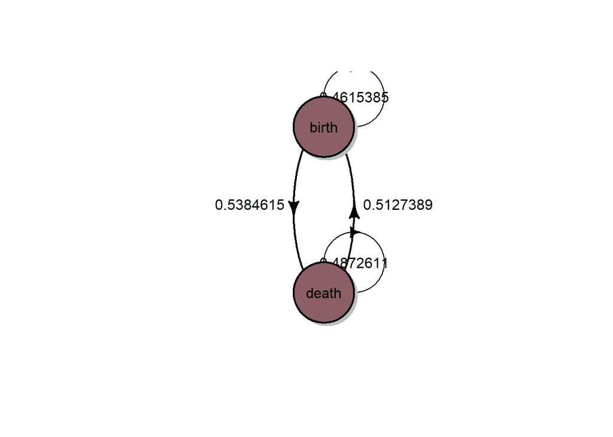

```r
mc = new("markovchain", states = colnames(TPM), transitionMatrix = TPM)

plot(mc, package = "diagram")
```

- **Death to Death (0.4872611)**: This suggests a moderate persistence in the death state, with a 48.73% chance of remaining in this state in the next time step.
- **Death to Birth (0.5127389)**: This indicates a slight inclination towards transitioning from death to birth, with a 51.27% probability.
- **Birth to Death (0.5384615)**: This reveals a higher volatility when in the birth state, with a 53.85% chance of transitioning to the death state in the next time step.
- **Birth to Birth (0.4615385)**: This suggests a moderate stability in the birth state, with a 46.15% chance of remaining in this state in the next time step.